# Economía popular en Colombia: EMICRON 2024

70 cuadros ponderados · minería de reglas de asociación · R + Quarto

Daniel Molina Barrios

10 de noviembre de 2026

LatinR 2026 · Medellín · trabajo aceptado

[figure not shown]

Economía popular en Colombia: ¿tres problemas o uno solo?

Informalidad fiscal, exclusión digital y restricción al crédito en 5.297.252 micronegocios, analizadas con estadística ponderada y minería de reglas de asociación sobre los microdatos abiertos de la EMICRON 2024 del DANE.

5.297.252

micronegocios

representados por 78.501 encuestas

77,6%

no tiene RUT

informalidad fiscal

50,4%

no tiene internet

exclusión digital

14,2%

solicitó crédito el último año

restricción financiera

**Daniel José Molina Barrios** · Economista & Data Scientist Datos: EMICRON 2024 — DANE · Actualizado el 10 de noviembre de 2026

[Repositorio y código](https://github.com/dmetrics1/micronegocios-colombia-2024) Diapositivas

# 1 Resumen ejecutivo

Colombia tiene 5,3 millones de micronegocios. Cuatro de cada cinco operan sin registro tributario, la mitad no tiene internet y solo 1 de cada 7 solicitó crédito en el último año. El reto no es la falta de emprendimiento sino la débil conexión de estos negocios con la infraestructura institucional, digital y financiera.

## 1.1 Indicadores clave

La Encuesta de Micronegocios 2024 del DANE (EMICRON) ofrece la radiografía más completa disponible sobre el tejido empresarial de base en Colombia. Con una muestra de 78.501 negocios que, mediante factores de expansión, representa a 5.297.252 unidades económicas, este análisis busca responder una pregunta fundamental: ¿bajo qué condiciones operan los micronegocios colombianos y qué características tienden a presentarse juntas?

Los datos describen un ecosistema con una vitalidad innegable —millones de colombianos que han optado por el autoempleo como estrategia de vida— atravesado por tres fracturas estructurales: informalidad fiscal, exclusión digital y restricción crediticia. La minería de reglas de asociación muestra que estas dimensiones **co-ocurren** de forma sistemática; al ser un análisis de asociación con datos de corte transversal, no permite afirmar relaciones de causalidad entre ellas.

| Indicador | Valor | Interpretación |
| --- | --- | --- |
| Universo expandido | 5,3 millones de negocios | Mercado amplio pero muy informal |
| Informalidad fiscal | 77,6% sin RUT | Formalización tributaria minoritaria |
| Brecha digital | 50,4% sin internet | El universo está partido en dos mitades |
| Acceso crediticio | 14,2% solicitó crédito | Bajísimo uso del financiamiento |
| Madurez empresarial | 47,4% con 10+ años | Mercado persistente con poca renovación |
| Tecnología móvil | 70,9% usa celular en el negocio | Puerta de entrada digital principal |

## 1.2 Hallazgos críticos

**Advertencia⚠️ Informalidad dual y reforzada**

El 77,6% de los micronegocios opera sin RUT y el 89,7% lo hace sin registro en Cámara de Comercio. Ambas cifras están estrechamente relacionadas: prácticamente ningún negocio sin RUT (0,04%) tiene registro mercantil. La informalidad en Colombia no es un fenómeno marginal ni transitorio; es la norma del tejido microempresarial, y es especialmente aguda en zonas rurales (94,0% sin RUT frente a 70,4% en cabeceras, según el boletín DANE).

**Importante🔴 Brecha digital en punto crítico**

El 50,4% de los micronegocios no tiene acceso a internet. La brecha entre el uso del celular (70,9%) y el acceso a internet (49,6%) es de 21,3 puntos porcentuales. El cruce de ambas variables muestra que el **21,6% de los micronegocios —1,15 millones— usa el celular para el negocio pero no tiene internet**: tienen el dispositivo pero no la conectividad, un grupo donde el costo marginal de completar la digitalización es presumiblemente menor.

**Tip💡 Las TIC co-ocurren como sistema acoplado**

Las tecnologías no aparecen de forma aislada. Entre los negocios que usan el celular y aceptan transferencias, la proporción que tiene internet en el local es 1,87 veces la que se observa en el conjunto (lift ponderado por el factor de expansión 1,87; 1,81 en la muestra). Esto es coherente con una adopción conjunta de herramientas digitales y sugiere que las intervenciones integrales podrían ser más pertinentes que las aisladas, aunque las reglas de asociación por sí solas no permiten estimar ese efecto.

**Nota📌 Tres grupos estructurales**

Cruzando conectividad (internet) y formalización fiscal (RUT) se obtienen tres grupos mutuamente excluyentes: **Excluidos** (sin internet ni RUT, 46,2%), **En transición** (solo una de las dos, 35,7%) e **Integrados** (ambas, 18,2%). Los grupos difieren de forma marcada en variables que no intervienen en su definición —uso de pagos digitales, registros contables, ahorro y crédito—, lo que refuerza su pertinencia descriptiva (ver sección de segmentación).

## 1.3 Metodología y fuentes

Este análisis integra dos niveles metodológicos complementarios:

**Estadística descriptiva ponderada.** Se produjeron 70 cuadros estadísticos aplicando el factor de expansión F_EXP del DANE, lo que permite que los resultados de la muestra representen al universo nacional de 5,3 millones de micronegocios. Diez indicadores clave de nueve cuadros se contrastaron con el Boletín Técnico oficial: nueve coinciden con diferencias inferiores a 0,1 puntos porcentuales y uno (participación de la agricultura) difiere en 1,06 puntos. La comprobación está automatizada en `tests/validar_resultados.R`.

**Minería de reglas de asociación (algoritmo Apriori).** Esta técnica detecta combinaciones de características que aparecen juntas con mayor frecuencia de la esperada si fueran independientes. Mientras la estadística descriptiva dice “el 70,9% usa celular”, el análisis Apriori responde “entre quienes usan celular y aceptan transferencias, tener internet es 1,87 veces más frecuente que en el total” (lift ponderado). Apriori se ejecutó sobre la muestra (77.202 registros completos de 78.501, 30 variables) y luego se recalcularon soporte, confianza y lift **ponderados por F_EXP** para reportar valores representativos del universo.

Los umbrales principales fueron soporte mínimo del 15% y confianza mínima del 70%, con reglas de dos a cuatro ítems (antecedentes de hasta tres). Se generaron 119.456 reglas, de las cuales 55.906 son no redundantes. La estabilidad de los resultados se evaluó en una rejilla de 16 combinaciones de umbrales (sección de robustez).

# 2 Módulo A — Resultados generales

> **Guía metodológica:** El Módulo A corresponde a las características más básicas e identitarias del propietario del micronegocio. Su función dentro del análisis es establecer el perfil demográfico y laboral de base sobre el cual se leerán todos los demás hallazgos. Los indicadores de este módulo responden la pregunta: ¿quién es el microempresario colombiano?

## 2.1 Situación en el empleo del propietario

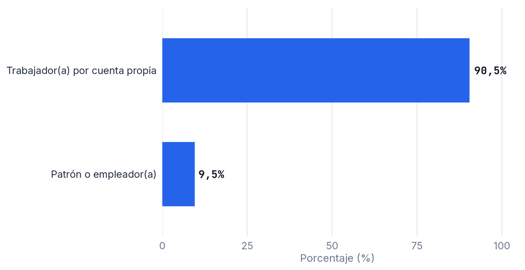

**Figura 1A:** Situación en el empleo: Cuenta propia vs. Empleador

El dato más definitorio del microempresariado colombiano es, al mismo tiempo, el más revelador sobre sus límites estructurales: el **90,46% de los propietarios opera como trabajador por cuenta propia**. Solo el 9,54% es patrón o empleador, es decir, tiene trabajadores remunerados a cargo.

Esta distribución no es únicamente un dato laboral; es un diagnóstico sobre la naturaleza misma del fenómeno microempresarial en Colombia. El micronegocio colombiano es, en su inmensa mayoría, una estrategia de autoempleo antes que una unidad de producción con vocación de escalamiento. Esto tiene implicaciones directas para el diseño de programas de apoyo: las intervenciones que asuman que estos negocios aspiran a crecer y contratar personal como objetivo primario estarán diseñando para el 10%, no para el 90%.

## 2.2 Sexo del propietario

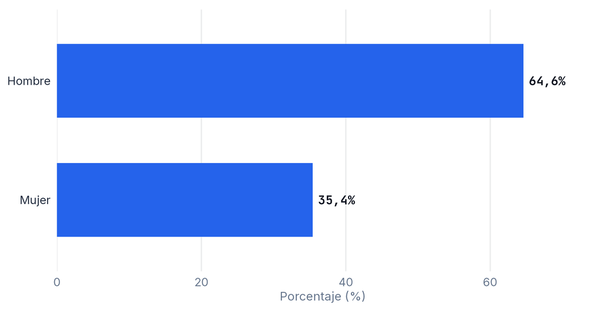

**Figura 1B:** Distribución por sexo del propietario

La distribución por sexo muestra que el **64,59% de los micronegocios está en manos de hombres y el 35,41% en manos de mujeres**.

El promedio nacional oculta una diferencia territorial importante: según el boletín DANE, **en las cabeceras municipales la participación femenina llega al 38,0%, mientras que en centros poblados y rural disperso desciende al 29,5%**, una brecha de 8,5 puntos porcentuales. Esta heterogeneidad es relevante para el diseño de políticas de género: una intervención homogénea que no distinga entre zonas urbanas y rurales puede subestimar las barreras adicionales que enfrentan las microempresarias rurales.

# 3 Módulo B — Sector económico

> **Guía metodológica:** El Módulo B caracteriza la actividad productiva de los micronegocios. Está construido en dos niveles de desagregación: una clasificación en 4 grandes grupos (que ofrece claridad estratégica) y una clasificación en 12 subsectores (que permite focalización por nicho).

## 3.1 Distribución sectorial (4 grupos principales)

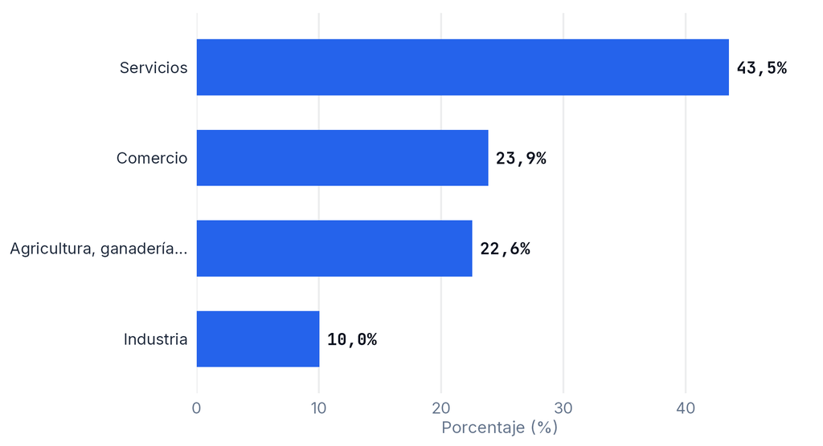

**Figura 2A:** Distribución sectorial: 4 grupos principales

La economía microempresarial colombiana se organiza alrededor de cuatro grandes sectores con proporciones muy distintas: **Servicios (43,54%), Comercio (23,86%), Agricultura (22,56%) e Industria (10,04%)**.

El predominio de los servicios —que concentran casi la mitad del ecosistema microempresarial— refleja una tendencia hacia economías de servicios que en el caso colombiano se expresa desde la base productiva más informal. La presencia significativa de la agricultura (22,56%), combinada con el comercio (23,86%), señala que casi la mitad del microempresariado opera en producción primaria o distribución de bienes. La baja participación industrial (10,04%) es coherente con un sector que en Colombia tiende a concentrarse en empresas medianas y grandes.

## 3.2 Distribución sectorial (12 subsectores)

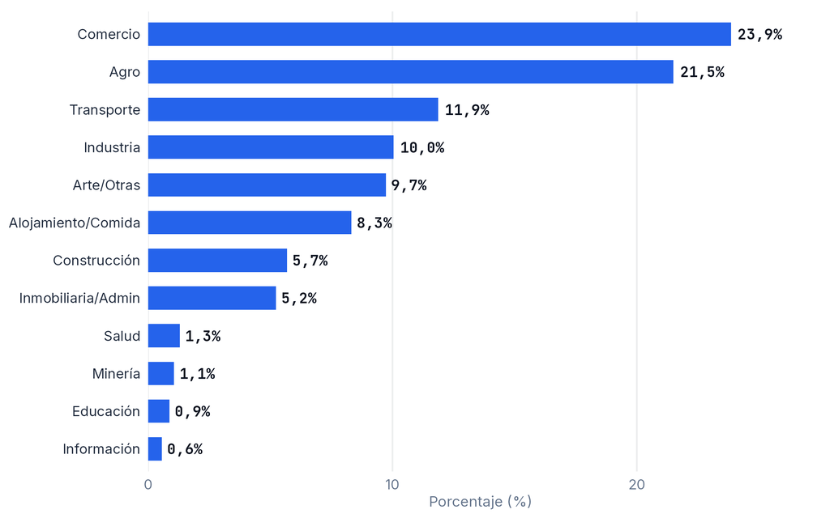

**Figura 2B:** Distribución sectorial: 12 categorías económicas

La desagregación a 12 subsectores revela una diversidad sectorial considerable: los cinco primeros subsectores —comercio (23,9%), agro (21,5%), transporte (11,9%), industria (10,0%) y artes y otros servicios (9,7%)— concentran el 77% del universo microempresarial.

# 4 Módulo C — Emprendimiento

> **Guía metodológica:** El Módulo C aborda dos dimensiones del ciclo de vida empresarial: la longevidad del negocio (tiempo de funcionamiento) y su estructura financiera de origen (fuente de financiación). Juntos, estos indicadores permiten responder la pregunta: ¿cómo nacen y cuánto llevan funcionando estos negocios?

## 4.1 Tiempo de funcionamiento

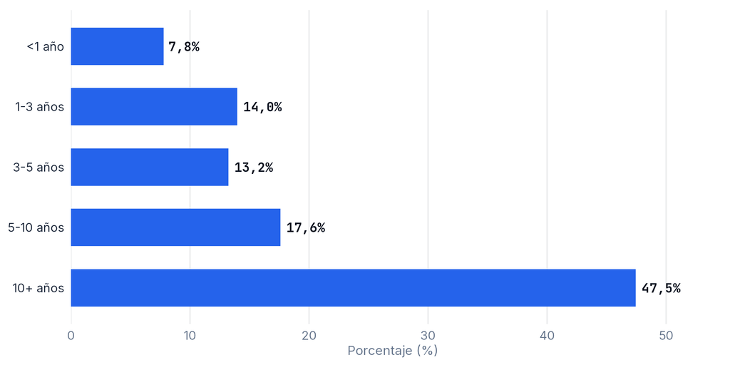

**Figura 3A:** Distribución por tiempo de funcionamiento

La distribución por tiempo de funcionamiento revela un rasgo sorprendente del microempresariado colombiano: **el 47,4% de los micronegocios lleva más de diez años en operación**, y el 65% supera los cinco años. Contra el estereotipo del emprendimiento frágil y efímero, el universo exhibe una notable persistencia.

Esta fortaleza tiene otra cara: solo el **7,8% tiene menos de un año de antigüedad**, lo que describe un mercado con baja renovación. Hay que leer este dato con cautela: la encuesta observa a los negocios que sobreviven, de modo que la proporción de negocios jóvenes también refleja la salida de los que no sobrevivieron.

## 4.2 Fuente de financiación inicial

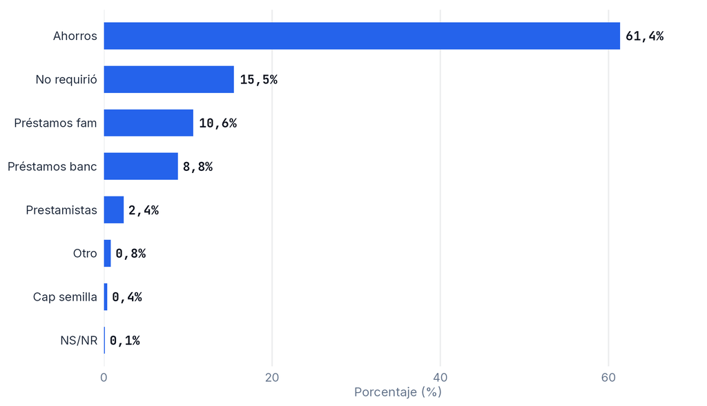

**Figura 3B:** Fuentes de financiación al inicio del negocio

La estructura de financiamiento con la que nacen los micronegocios es uno de los indicadores más elocuentes sobre la distancia entre el sistema financiero formal y la economía popular: **el 61,4% se financió con ahorros propios y el 15,5% no requirió financiación**. Sumados, el 76,8% de los micronegocios surgió sin ningún vínculo con el crédito.

Solo el **8,8% accedió a préstamos bancarios** al inicio, y un **2,4% recurrió a prestamistas**. Entre quienes solicitaron crédito en el último año (el 14,2% del universo), el **22,9% lo hizo con prestamistas “gota a gota”**: casi uno de cada cuatro microempresarios que busca financiamiento lo hace en el mercado informal.

# 5 Módulos D-E — Ubicación y operación

> **Guía metodológica:** Los Módulos D y E se analizan conjuntamente porque describen las condiciones físicas y de escala de la operación: dónde funciona el negocio y cuántas personas lo sostienen.

## 5.1 Ubicación principal del negocio

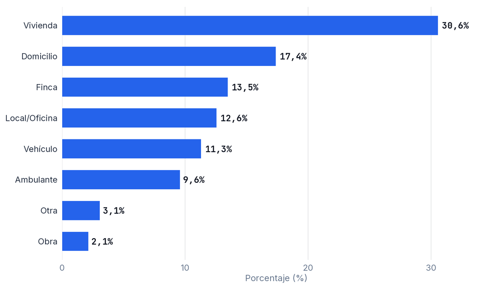

**Figura 4A:** Ubicación principal del negocio

La distribución de la ubicación confirma una informalidad que va más allá de lo fiscal: también es espacial. **El 30,56% opera desde la vivienda del propietario**, el **17,37% puerta a puerta** y el **9,58% de forma ambulante**; sumados, el 57,5% opera en la vivienda, puerta a puerta o en la calle, sin un local comercial fijo. El 13,46% que opera en fincas corresponde fundamentalmente a la actividad agropecuaria.

Un negocio que opera desde la sala de la casa o en la calle es, desde el punto de vista institucional, casi invisible. Las estrategias de formalización que exigen un local físico como requisito están excluyendo a más de la mitad del universo antes de empezar.

## 5.2 Personal ocupado

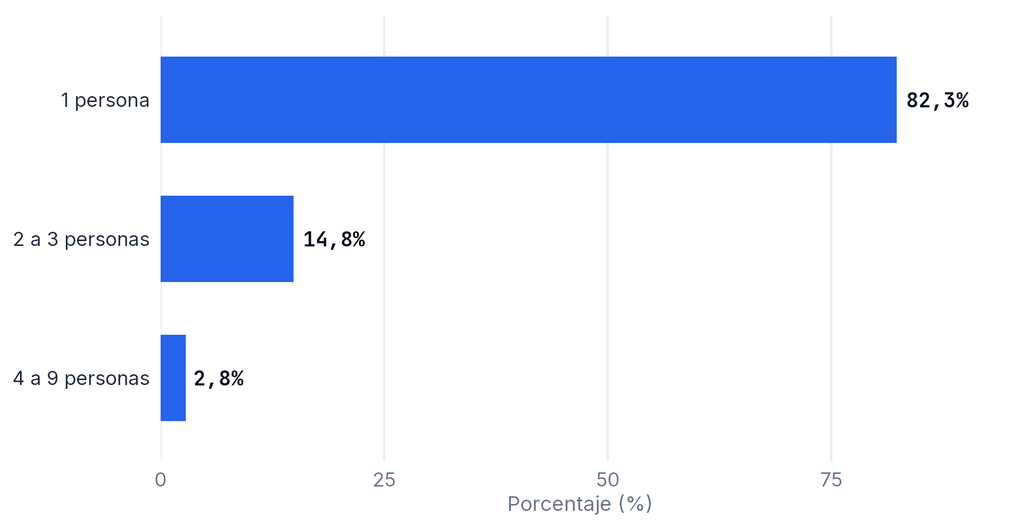

**Figura 4B:** Personal ocupado en el micronegocio

La distribución del personal ocupado refuerza el perfil del autoempleo: **el 82,3% de los micronegocios es una operación unipersonal**, sostenida exclusivamente por su propietario. El 14,9% ocupa entre dos y tres personas y solo el 2,8% entre cuatro y nueve. El personal ocupado incluye al propietario, los trabajadores remunerados, los socios y los familiares sin remuneración; con esta definición el pipeline reproduce el total del boletín DANE (6.879.489 personas ocupadas).

En términos absolutos, el 82,3% equivale a aproximadamente **4,36 millones de negocios** en los que el propietario es simultáneamente gerente, operario, vendedor y contador. Cualquier evento que afecte al propietario interrumpe toda la operación.

## 5.3 Personal promedio por sector económico

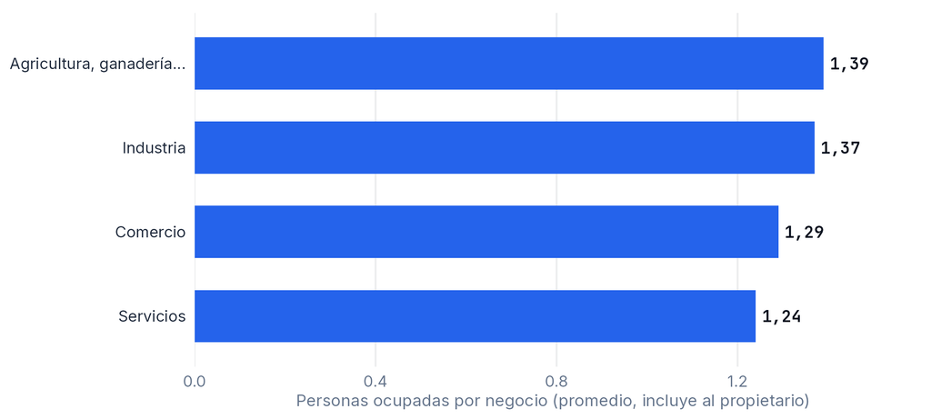

**Figura 4C:** Personal promedio por sector económico

El personal promedio por negocio es bajo en todos los sectores y varía poco: 1,39 personas en agricultura, 1,37 en industria, 1,29 en comercio y 1,24 en servicios. Las actividades agropecuarias e industriales tienden a involucrar algo más de personal —con frecuencia familiar—, mientras que los servicios son los más unipersonales.

# 6 Módulo F — Formalización

> **Guía metodológica:** El Módulo F contiene tres indicadores que definen la relación del micronegocio con el Estado: el RUT (relación tributaria), la contabilidad (capacidad de gestión interna) y el registro en Cámara de Comercio (reconocimiento legal-administrativo).

## 6.1 Tenencia de RUT

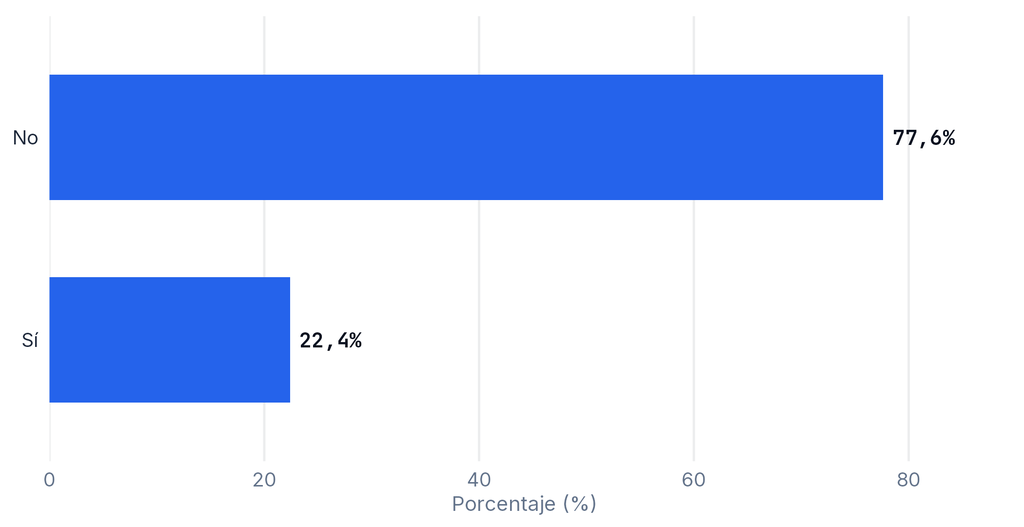

**Figura 5A:** Tenencia de Registro Único Tributario

El Registro Único Tributario (RUT) es la puerta de entrada al sistema tributario formal en Colombia. Sin él, un negocio no puede emitir facturas electrónicas, acreditar ingresos ante una entidad financiera ni participar en contratación pública.

**El 77,61% de los micronegocios colombianos no tiene RUT**: más de cuatro millones de unidades económicas operan fuera del registro tributario. La variación territorial es marcada: según el boletín DANE, en centros poblados y rural disperso el porcentaje sin RUT llega al **94,0%**, frente al **70,4%** en las cabeceras municipales.

## 6.2 Tipo de contabilidad

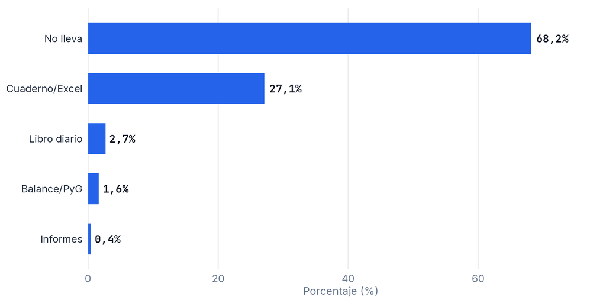

**Figura 5B:** Tipo de contabilidad llevada por el negocio

**El 68,2% no lleva ningún tipo de registro**; el 27,1% utiliza un cuaderno, una hoja de cálculo u otro registro informal; y solo el **1,6% lleva un balance general o estado de pérdidas y ganancias**. En conjunto, el 95,3% no lleva contabilidad formal.

Esta condición coincide con el bajo uso del crédito (85,8% no solicitó crédito en el último año): sin registros que demuestren flujo de caja, el acceso al financiamiento formal se dificulta. Ambos rasgos se presentan juntos, aunque los datos no permiten establecer cuál antecede al otro.

## 6.3 Registro en Cámara de Comercio

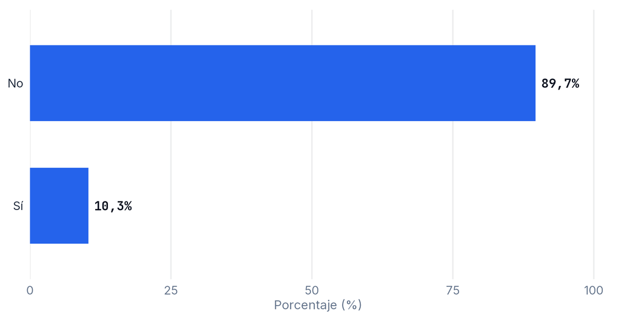

**Figura 5C:** Registro en Cámara de Comercio

**El 89,7% de los micronegocios no está registrado en ninguna Cámara de Comercio**; solo el 10,3% ha completado este trámite, requisito para muchos programas de apoyo empresarial y para contratar con otras empresas.

La combinación de los tres indicadores describe una **informalidad dual y reforzada**: el negocio que no tiene RUT, en la práctica, tampoco tiene registro mercantil y con frecuencia tampoco lleva registros contables.

# 7 Módulo G — Tecnología

> **Guía metodológica:** El Módulo G examina la relación de los micronegocios con las TIC a través de tres indicadores: dispositivos electrónicos (computador o tableta), celular e internet. Las brechas entre ellos son tan importantes como los valores individuales.

## 7.1 Dispositivos electrónicos

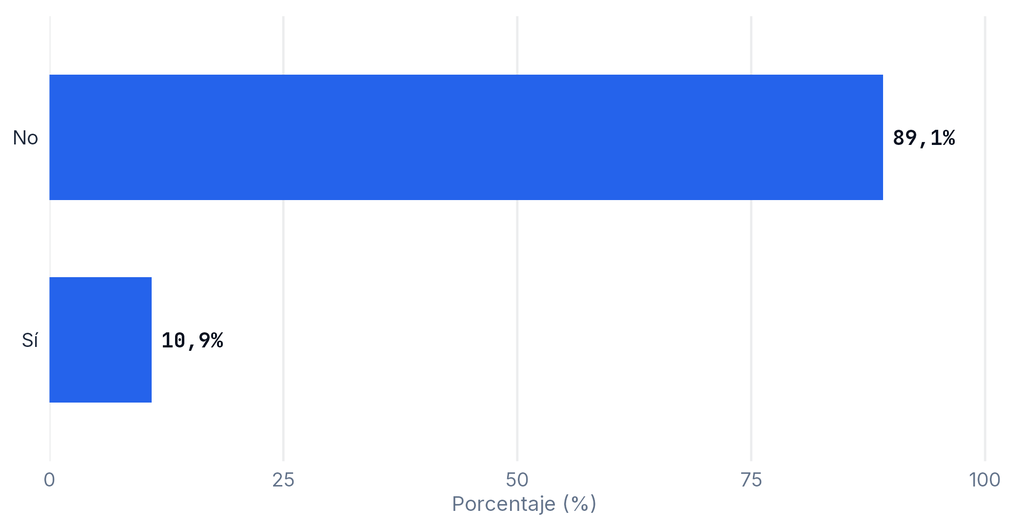

**Figura 6A:** Tenencia de dispositivos electrónicos

**El 89,09% de los micronegocios no usa ningún dispositivo electrónico** —computador, tableta u otro equipo diferente al celular—. Solo el 10,91% cuenta con alguno. Las soluciones de escritorio llegarán al 11% que ya tiene los medios para usarlas, no al 89% que más las necesita.

## 7.2 Uso de celular

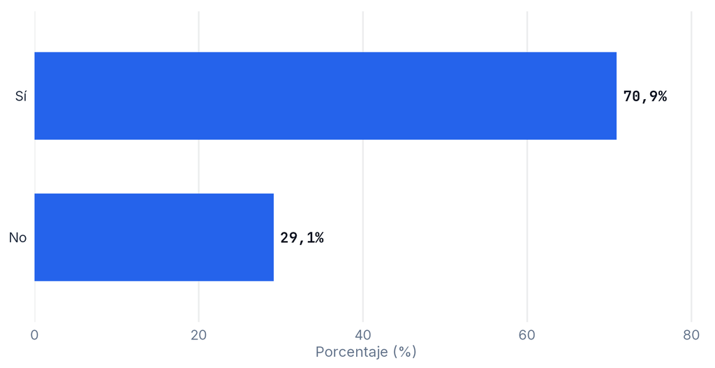

**Figura 6B:** Uso de celular como herramienta del negocio

El celular es, con enorme distancia, la tecnología más extendida: **el 70,9% usa el celular para su actividad**. La brecha de 60 puntos porcentuales frente a los dispositivos electrónicos muestra que el teléfono móvil es la plataforma con mayor capacidad de llegada a este universo. Cualquier solución de digitalización, pagos o contabilidad que no funcione en un celular de gama media llegará, en el mejor de los casos, a una fracción del universo objetivo.

## 7.3 Uso de internet

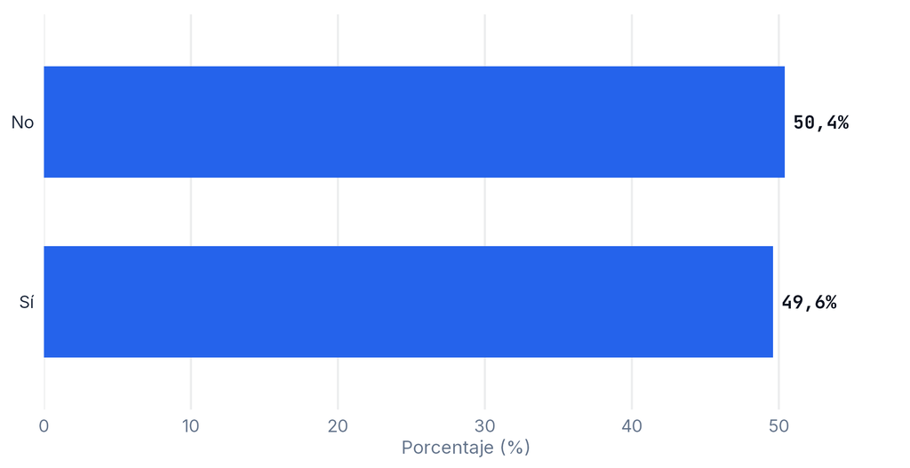

**Figura 6C:** Acceso y uso de internet en el negocio

**El 50,4% de los micronegocios no tiene acceso a internet**. La brecha digital está exactamente en el punto de equilibrio: el universo está partido en dos mitades.

El cruce entre celular e internet muestra que **1,15 millones de negocios (21,6% del universo) usan el celular para el negocio pero no tienen internet**. Esta población tiene el dispositivo pero no la conectividad.

# 8 Módulo H — Inclusión financiera

> **Guía metodológica:** El Módulo H examina la relación de los micronegocios con el sistema financiero desde dos ángulos: el acceso al crédito y el hábito de ahorro.

## 8.1 Solicitud de crédito

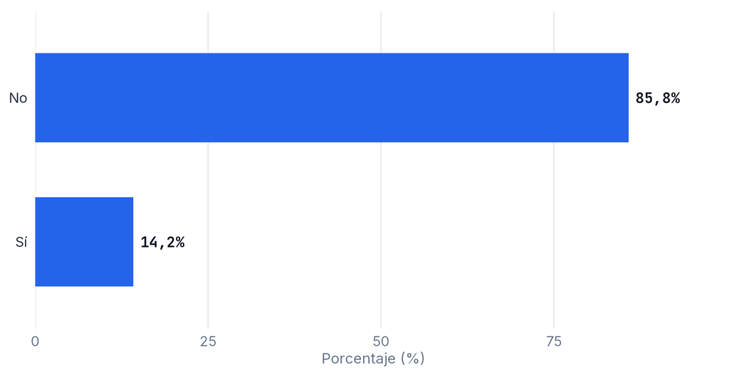

**Figura 7A:** Solicitud de crédito en el período de referencia

**El 85,8% no solicitó ningún crédito** en el año anterior; solo el 14,2% lo intentó.

Esta cifra admite varias lecturas compatibles entre sí: una preferencia por el autofinanciamiento (el 61,4% inició con ahorros propios), la percepción de que los requisitos del sistema financiero —RUT, contabilidad, garantías— son inalcanzables, y una oferta de productos poco adaptada al perfil del micronegocio informal. La encuesta incluye las razones declaradas para no solicitar crédito (cuadro H3), que permiten profundizar en cada una.

## 8.2 Hábito de ahorro

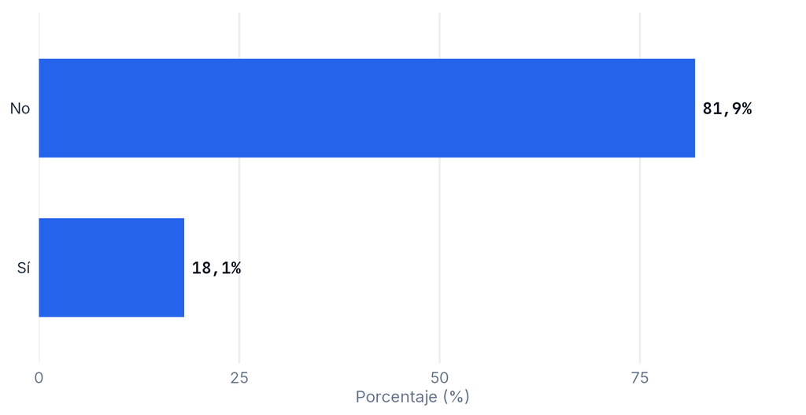

**Figura 7B:** Hábito de ahorro del propietario

**Solo el 18,1% ahorró dinero del negocio en el año anterior**; el 81,9% no lo hizo. El ahorro es más frecuente entre los negocios integrados (31,1%) que entre los excluidos (11,6%), como se muestra en la sección de segmentación.

# 9 Módulos J + V — Geografía e ingresos

> **Guía metodológica:** Esta sección combina la distribución geográfica de los micronegocios por departamento y la distribución de ingresos por sector.

## 9.1 Distribución geográfica de micronegocios por departamento

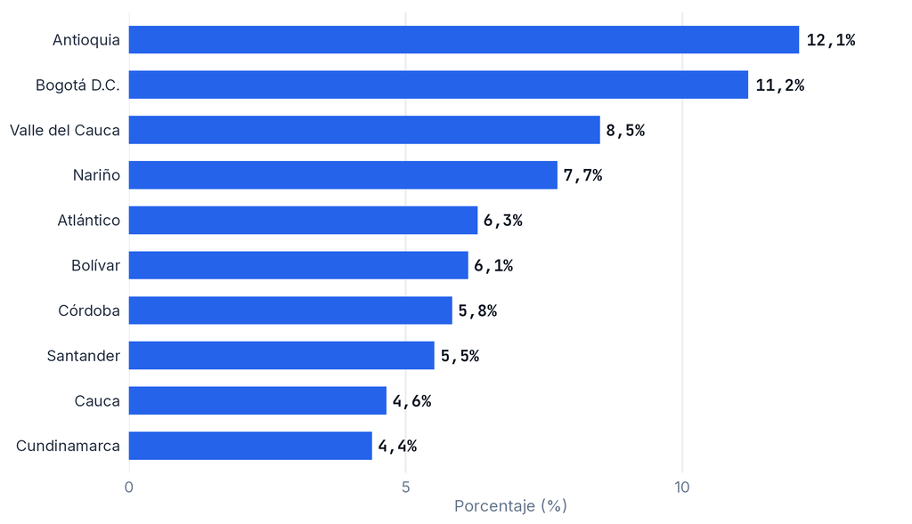

**Figura 8A:** Micronegocios por departamento: Top 10

La distribución geográfica refleja la distribución de la población y la actividad económica: los tres principales territorios —Antioquia (12,1%), Bogotá D.C. (11,2%) y Valle del Cauca (8,5%)— concentran el 31,8% del universo. Como en el boletín departamental del DANE, estas participaciones usan el factor de expansión departamental (`FEX_C`), que suma 5.262.313 micronegocios en los 24 departamentos y Bogotá.

La focalización de programas de conectividad debería cruzar la densidad de micronegocios con las tasas de desconexión departamentales (cuadro J2) para identificar los territorios prioritarios.

## 9.2 Ingresos totales por sector económico

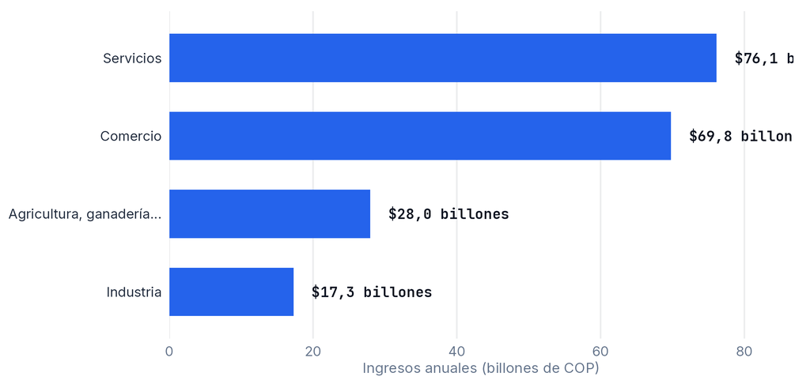

**Figura 8B:** Ingresos de 2024 por sector, en billones de pesos

La distribución de ingresos introduce la dimensión de productividad diferenciada: el **comercio concentra el 36,5% de los ingresos con el 23,9% de los negocios**, mientras que los **servicios generan el 39,8% de los ingresos con el 43,5% de los negocios**. El éxito de los programas de apoyo no puede medirse solo por el número de beneficiarios, sino también por el ingreso por beneficiario.

# 10 Minería de reglas de asociación (Apriori)

> **Guía metodológica:** Esta sección pasa de la fotografía (qué tienen o no los negocios) a las co-ocurrencias (qué características aparecen juntas). Las reglas describen asociaciones en datos de corte transversal; no identifican causas ni secuencias temporales.

## 10.1 Marco conceptual: de la descripción a los patrones

Los datos descriptivos dicen qué tiene o no tiene cada micronegocio. La pregunta relacional es otra: ¿qué viene con qué? Si un negocio usa el celular, ¿es más probable que también tenga internet? ¿La tenencia de RUT va acompañada de pagos digitales?

Para responder usamos **minería de reglas de asociación con el algoritmo Apriori** (paquete `arules`). Una regla {A} ⇒ {B} se evalúa con tres medidas:

- **Soporte:** proporción de negocios que tienen A y B a la vez.
- **Confianza:** entre los negocios con A, proporción que también tiene B.
- **Lift:** confianza dividida por la proporción general de B. Un lift de 1 indica independencia; un lift de 1,81 indica que B es 1,81 veces más frecuente entre quienes tienen A que en el total.

## 10.2 Parámetros metodológicos

- **Datos:** 30 variables categóricas (formalización, TIC, medios de pago, sector, antigüedad, perfil del propietario, emprendimiento, ubicación, seguridad social, declaraciones tributarias e inclusión financiera), recodificadas en 99 ítems sobre 77.202 registros completos (de 78.501), cuyos factores de expansión suman 5.203.185 negocios. En las preguntas de selección múltiple (formas de pago, TIC) la no respuesta se interpreta como “No”.
- **Soporte mínimo 15%:** cada patrón debe observarse en al menos ~11.600 registros de la muestra (en términos ponderados, el 15% de 5.203.185 equivale a unos 780.000 negocios). El umbral prioriza patrones con peso poblacional suficiente para informar política pública y evita reglas sobre nichos pequeños.
- **Confianza mínima 70%:** la regla debe cumplirse en al menos 7 de cada 10 casos con el antecedente.
- **Longitud mínima 2 y máxima 4:** antecedentes de uno a tres ítems, para que las reglas sean interpretables.
- **Reglas redundantes:** se eliminaron con `arules::is.redundant()`. Una regla es redundante si existe otra más general (con un subconjunto de su antecedente y el mismo consecuente) con igual o mayor confianza: la condición adicional no aporta información. De 119.456 reglas quedaron 55.906 no redundantes.
- **Factores de expansión:** `apriori()` trata cada registro con igual peso. Para que las medidas representen al universo se asignó F_EXP como peso de cada transacción y se recalcularon soporte, confianza y lift ponderados con `arules::support(..., weighted = TRUE)` (función `medidas_ponderadas()` en `scripts/00_config.R`). En las tablas siguientes se reportan ambas versiones.

## 10.3 Hallazgos principales

Reglas clave con medidas muestrales y ponderadas por F_EXP (fuente: output/tablas/12a_reglas_clave.csv)

| Hallazgo | Regla | Soporte (pond.) | Confianza (pond.) | Lift muestral | Lift ponderado |
| --- | --- | --- | --- | --- | --- |
| Exclusión digital acumulada | sin computador ni tableta + sin celular de negocio + sin transferencias ⇒ sin internet en el local | 27,6% | 99,6% | 1,97 | 1,90 |
| Sin celular → sin internet | sin celular de negocio ⇒ sin internet en el local | 28,5% | 98,9% | 1,96 | 1,89 |
| TIC acopladas | usa celular + acepta transferencias ⇒ internet en el local | 34,0% | 89,3% | 1,81 | 1,87 |

- **Exclusión digital acumulada.** Los negocios sin dispositivos electrónicos, sin celular para el negocio y sin transferencias casi nunca tienen internet en el local (confianza 99,6%; lift ponderado 1,90). El patrón abarca al 27,6% del universo según el soporte ponderado, unos 1,44 millones de negocios (27,6% de 5.203.185): la ausencia de una herramienta digital tiende a coincidir con la ausencia de las demás.
- **Sin celular, sin internet.** La sola ausencia del celular ya se asocia con no tener internet en 98,9% de los casos.
- **TIC acopladas.** Entre quienes usan celular y aceptan transferencias, el 89,3% tiene internet en el local; el lift ponderado (1,87) es incluso mayor que el muestral.
- **RUT y pagos digitales.** La regla con mayor lift de todo el análisis es {tiene RUT, usa celular} ⇒ {acepta transferencias} (confianza ponderada 81,5%; lift ponderado 2,08, 2,01 en la muestra): la formalización fiscal aparece fuertemente asociada a los pagos digitales.

**Sobre el RUT.** Con los umbrales principales no aparece ninguna regla cuyo consecuente sea tener RUT. Esto **no** significa que el RUT sea independiente del resto del sistema. La ausencia de reglas se explica por el umbral de soporte: los negocios con RUT son el 22,4% del universo, y las combinaciones que mejor lo acompañan son menos frecuentes que el 15%. Al bajar el soporte al 5% y excluir las demás variables de formalización (sección de robustez) aparecen reglas formadas solo por variables digitales y de ubicación; la de mayor confianza es {internet en el local, acepta transferencias, local fijo} ⇒ {tiene RUT}, con confianza ponderada de 76,9% y lift ponderado de 3,44. La formalización fiscal está asociada a la digitalización y al local fijo, aunque en segmentos más pequeños del universo.

## 10.4 Visualizaciones Apriori

**Figura 9A — Frecuencia de ítems**

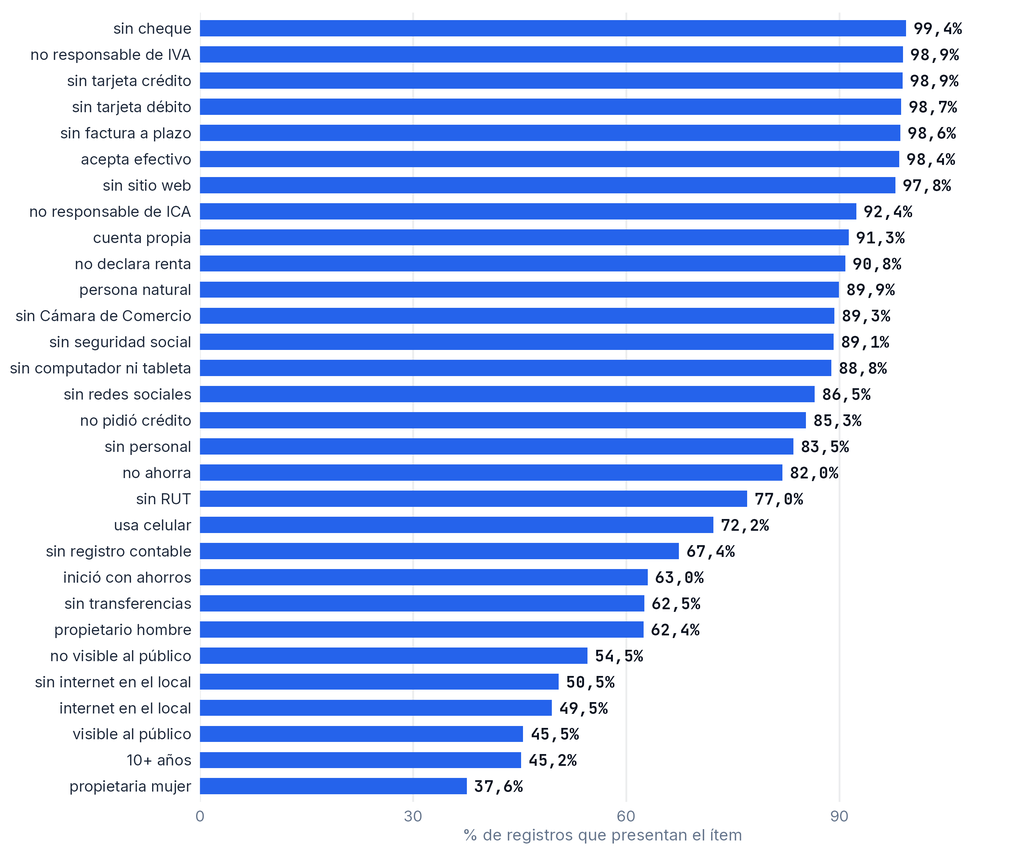

**Figura 9A:** Frecuencia de los 30 ítems más comunes en las transacciones

Muestra la proporción de negocios que presenta cada característica (soporte de cada ítem). Dominan los ítems de ausencia —no aceptar cheques ni tarjetas, no ser responsable de IVA, no tener sitio web—, presentes en más del 97% de los registros, lo que explica que muchas de las reglas frecuentes describan patrones de exclusión.

**Figura 9B — Soporte vs. confianza**

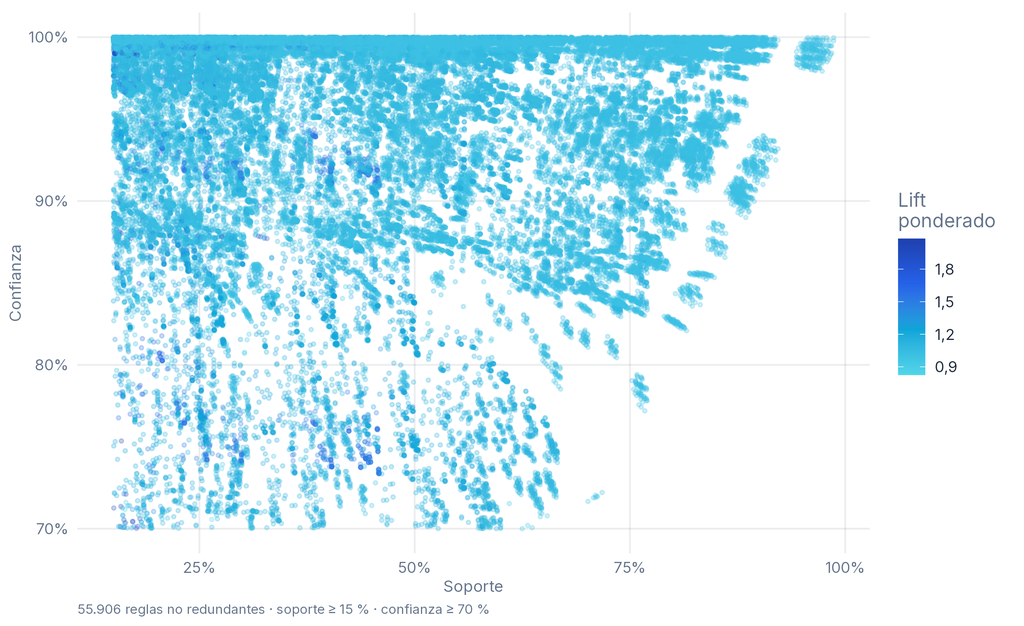

**Figura 9B:** Soporte (eje horizontal) vs. confianza (eje vertical), color según lift

Cada punto es una regla no redundante: la posición horizontal indica qué tan común es el patrón (soporte), la vertical qué tan seguido se cumple (confianza) y el color su lift. De las 251 reglas con lift muestral superior a 1,9, el 99% tiene como consecuente “sin internet en el local”: los patrones más fuertes son de exclusión digital.

**Figura 9C — Top 20 reglas por lift**

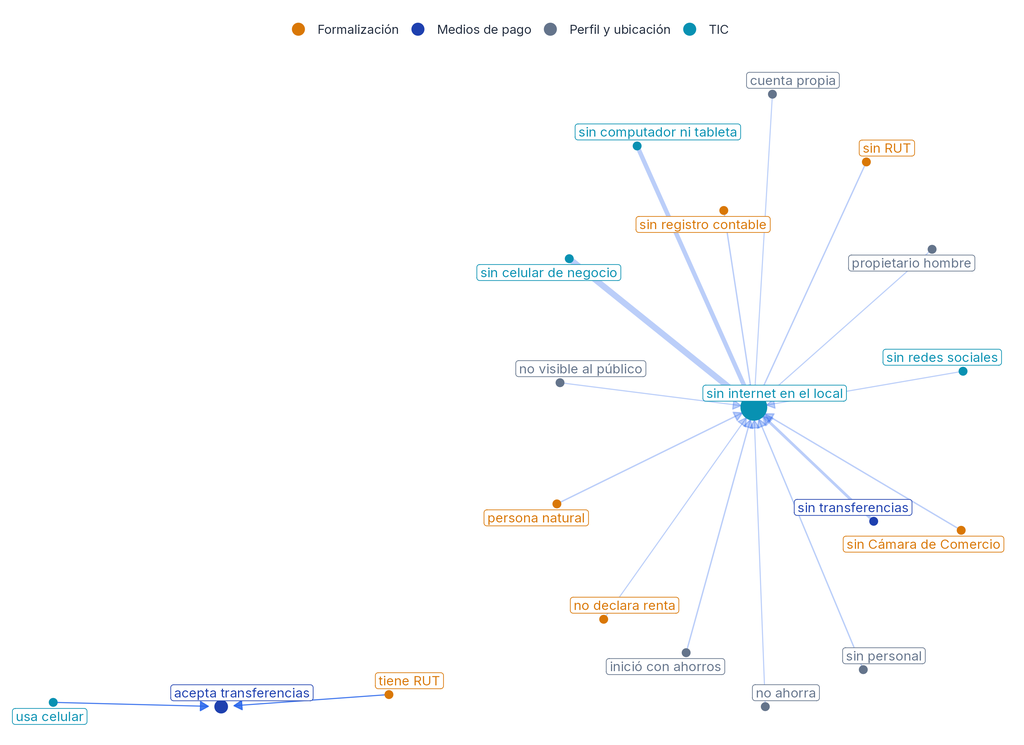

**Figura 9C:** Grafo de las 20 reglas con mayor lift

Diecinueve de las veinte reglas con mayor lift combinan la ausencia de dispositivos, celular, transferencias o registros contables y desembocan en “sin internet en el local”. La excepción —y la regla de mayor lift— es {tiene RUT, usa celular} ⇒ {acepta transferencias}.

**Figura 9D — Antecedentes × consecuentes**

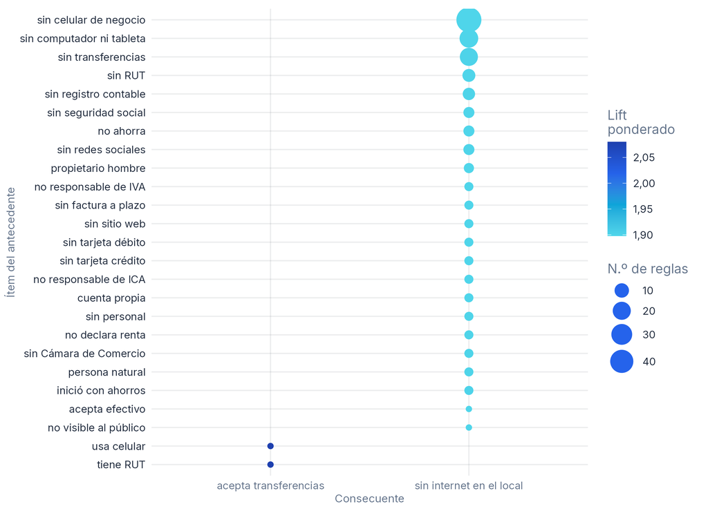

**Figura 9D:** Ítems del antecedente y consecuentes de las 50 reglas con mayor lift (tamaño = n.º de reglas, color = lift ponderado)

Cada punto cruza un ítem que aparece en el antecedente con el consecuente de la regla, entre las 50 reglas con mayor lift. Un número reducido de ítems —ligados a la ausencia de herramientas digitales— se repite en buena parte de las reglas más fuertes, y casi todas desembocan en “sin internet en el local”.

**Figura 9E — Reglas hacia pagos digitales**

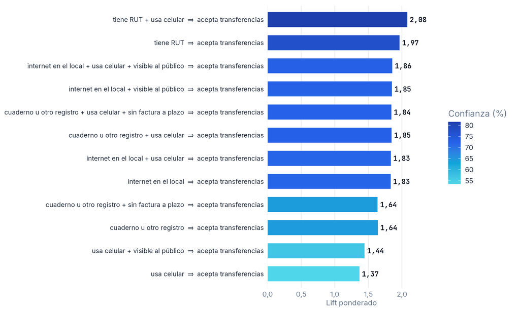

**Figura 9E:** Las 12 reglas con mayor lift hacia la aceptación de transferencias (barra = lift ponderado, color = confianza ponderada)

Muestra las combinaciones de ítems que acompañan la aceptación de transferencias. El RUT, el internet en el local y el celular aparecen de forma recurrente en estas combinaciones. Al ser datos de corte transversal, el gráfico no describe una secuencia temporal de adopción.

**Figura 9F — Red de relaciones: negocios de 10+ años**

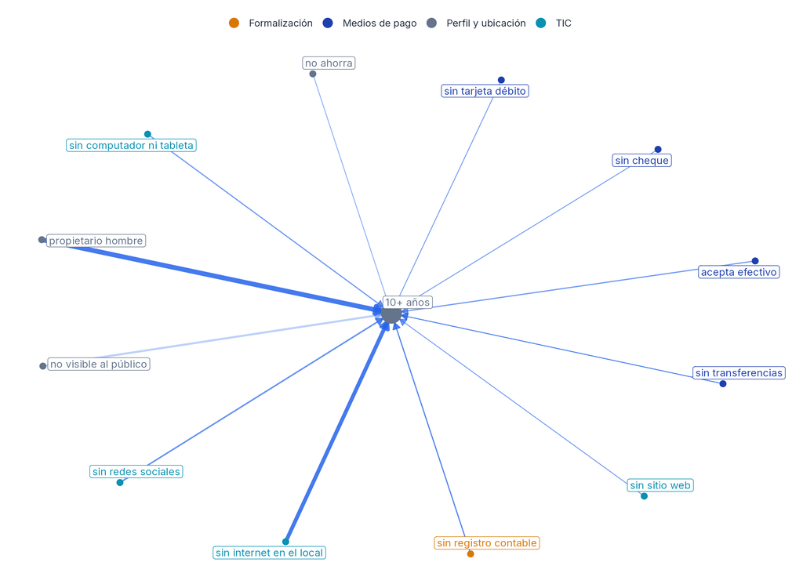

**Figura 9F:** Grafo de las reglas hacia negocios con 10 o más años

Los negocios con más de diez años se asocian con no usar redes sociales ni dispositivos electrónicos, no ser visibles al público y propietario hombre. Son asociaciones moderadas (lift ponderado entre 1,21 y 1,31): describen un perfil, no una regla rígida.

# 11 Robustez de los resultados

> **Guía metodológica:** Esta sección evalúa si los hallazgos dependen de las decisiones metodológicas: los umbrales de soporte y confianza, y el uso o no de los factores de expansión. Todo se calcula en `scripts/07_sensibilidad_apriori.R`.

## 11.1 Sensibilidad a los umbrales

Número de reglas y presencia de las reglas clave según umbrales (fuente: output/tablas/12_sensibilidad_umbrales.csv)

| Soporte | Confianza | Reglas | No redundantes | Exclusión acumulada | Sin celular → sin internet | TIC acopladas |
| --- | --- | --- | --- | --- | --- | --- |
| 10% | 60% | 204.478 | 83.119 | ✓ | ✓ | ✓ |
| 10% | 70% | 183.731 | 77.115 | ✓ | ✓ | ✓ |
| 10% | 80% | 170.138 | 73.011 | ✓ | ✓ | ✓ |
| 10% | 90% | 130.086 | 59.769 | ✓ | ✓ | — |
| 15% | 60% | 135.492 | 61.173 | ✓ | ✓ | ✓ |
| 15% | 70% | 119.456 | 55.906 | ✓ | ✓ | ✓ |
| 15% | 80% | 110.805 | 52.357 | ✓ | ✓ | ✓ |
| 15% | 90% | 83.635 | 42.253 | ✓ | ✓ | — |
| 20% | 60% | 111.580 | 55.149 | ✓ | ✓ | ✓ |
| 20% | 70% | 99.353 | 50.971 | ✓ | ✓ | ✓ |
| 20% | 80% | 92.723 | 47.636 | ✓ | ✓ | ✓ |
| 20% | 90% | 70.649 | 38.346 | ✓ | ✓ | — |
| 25% | 60% | 91.825 | 49.109 | ✓ | ✓ | ✓ |
| 25% | 70% | 82.290 | 45.769 | ✓ | ✓ | ✓ |
| 25% | 80% | 77.034 | 42.704 | ✓ | ✓ | ✓ |
| 25% | 90% | 60.192 | 34.724 | ✓ | ✓ | — |

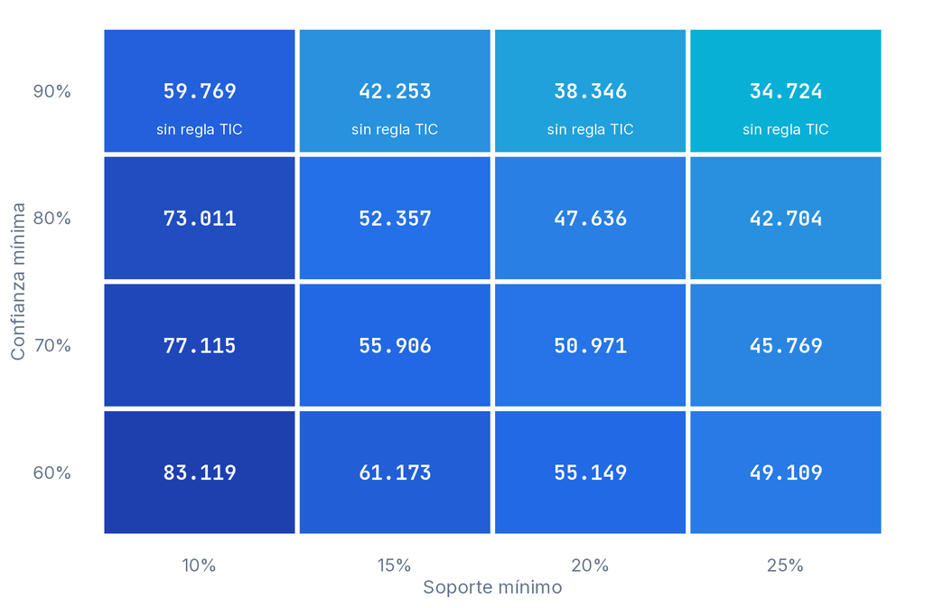

**Figura 10A:** Reglas no redundantes según los umbrales de soporte y confianza

El número de reglas varía con los umbrales —como es esperable—, pero los patrones centrales se mantienen. Las dos reglas de exclusión digital aparecen en las 16 combinaciones evaluadas. La regla de TIC acopladas aparece en todas las combinaciones con confianza de hasta 80%; se cae solo al exigir 90%, porque su confianza muestral es de 89,6%.

## 11.2 Medidas muestrales vs. ponderadas

Comparación del conjunto de reglas con y sin factores de expansión (fuente: output/tablas/12b_ponderado_vs_muestral.csv)

| Medida | Valor |
| --- | --- |
| Reglas conjunto muestral (supp≥15%, conf≥70%) | 55.906 |
| Reglas conjunto ponderado (supp≥15%, conf≥70%) | 60.207 |
| Reglas en ambos conjuntos | 55.282 |
| Índice de Jaccard entre conjuntos | 0,9088 |
| Correlación lift muestral vs ponderado | 0,9958 |
| Diferencia absoluta máxima en lift | 1,4220 |
| Diferencia absoluta máxima en soporte (p.p.) | 8,3800 |
| Diferencia absoluta máxima en confianza (p.p.) | 15,2700 |
| Coincidencia top 30 por lift (Jaccard) | 0,3333 |
| Soporte muestral mínimo entre reglas del conjunto ponderado | 0,0865 |

Incorporar F_EXP no altera las conclusiones. El 99% de las reglas del conjunto muestral (55.282 de 55.906) también cumple los umbrales al ponderar, y la correlación entre el lift muestral y el ponderado es de 0,996. El orden fino de las reglas sí cambia —la mitad del top 30 por lift coincide (índice de Jaccard 0,33)—, porque las 30 reglas de mayor lift tienen valores casi idénticos (entre 1,97 y 2,01) y pequeñas variaciones reordenan la lista. Por eso este análisis se apoya en patrones y no en la posición exacta de una regla en el ranking.

Para construir el conjunto ponderado se mineró con un soporte muestral de 8%: al ponderar, el soporte de algunas reglas cambia hasta 8,4 puntos, y el soporte muestral mínimo entre las reglas del conjunto ponderado fue de 8,65%. Bajar el piso al 6% no agrega ninguna regla.

## 11.3 ¿Qué se asocia con tener RUT?

Mejores reglas hacia tiene_rut=Sí con soporte ≥ 5%, excluyendo otras variables de formalización como antecedente (fuente: output/tablas/12d_reglas_rut_sin_formalizacion.csv)

| Regla | Soporte (pond.) | Confianza (pond.) | Lift ponderado |
| --- | --- | --- | --- |
| internet en el local + acepta transferencias + local fijo ⇒ tiene RUT | 5,8% | 76,9% | 3,44 |
| acepta transferencias + local fijo + visible al público ⇒ tiene RUT | 6,0% | 75,5% | 3,38 |
| usa celular + acepta transferencias + local fijo ⇒ tiene RUT | 6,4% | 75,8% | 3,39 |
| acepta transferencias + local fijo ⇒ tiene RUT | 6,5% | 75,6% | 3,38 |
| internet en el local + usa computador o tableta + acepta transferencias ⇒ tiene RUT | 7,5% | 76,4% | 3,42 |

Si se permiten todas las variables como antecedente, las reglas hacia el RUT tienen confianza cercana al 100%, pero son casi tautológicas: declarar renta o estar en Cámara de Comercio exige tener RUT (ver `output/tablas/12c_reglas_rut.csv`). Al excluir esas variables, las combinaciones de internet, transferencias, dispositivos y local fijo acompañan al RUT con confianza ponderada de 75–77% y lift ponderado de 3,4. **El RUT no es exógeno al sistema: está asociado con la digitalización y con tener un local fijo**, en segmentos que abarcan alrededor del 6% del universo.

# 12 Segmentación: tres grupos estructurales

> **Guía metodológica:** Los grupos se definen en `scripts/06_segmentacion.R` a partir de dos variables —acceso a internet (P2524) y tenencia de RUT (P1633)—, que representan las dos fracturas centrales del diagnóstico. Todas las cifras están ponderadas por F_EXP.

## 12.1 Definición

| Grupo | Definición |
| --- | --- |
| **Excluidos** | Sin internet y sin RUT |
| **En transición** | Solo una de las dos: internet sin RUT, o RUT sin internet |
| **Integrados** | Con internet y con RUT |

La tabla 2 × 2 produce grupos **mutuamente excluyentes y exhaustivos**: cada micronegocio pertenece a exactamente uno. El crédito, el ahorro, los pagos digitales y el celular no intervienen en la definición; se usan después para describir a cada grupo, de modo que la caracterización no es circular.

## 12.2 Tamaño de los grupos

Tamaño de los grupos (fuente: output/tablas/11_segmentacion_grupos.csv)

| Grupo | Muestra | Negocios (universo) | % |
| --- | --- | --- | --- |
| Excluidos | 34.130 | 2.446.032 | 46,2% |
| En transición | 29.691 | 1.888.949 | 35,7% |
| Integrados | 14.680 | 962.271 | 18,2% |

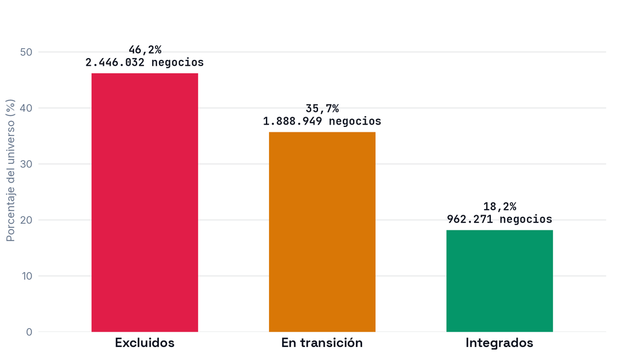

**Figura 11A:** Distribución de los micronegocios en los tres grupos

Casi la mitad del universo está en el grupo de **excluidos** (46,2%, 2,45 millones). El grupo **en transición** (35,7%) está compuesto casi por completo por negocios con internet pero sin RUT (31,4% del universo); los negocios con RUT pero sin internet son solo el 4,2%. Los **integrados** son el 18,2% (962.000 negocios).

## 12.3 Perfil de los grupos

Perfil ponderado por grupo con variables que no definen los grupos (fuente: output/tablas/11b_perfil_grupos.csv)

| Indicador | Excluidos | En transición | Integrados | Total |
| --- | --- | --- | --- | --- |
| Usa celular para el negocio | 41,1% | 95,0% | 99,3% | 70,9% |
| Acepta transferencias | 5,7% | 57,6% | 86,9% | 38,9% |
| Lleva algún registro contable | 12,6% | 34,5% | 75,4% | 31,8% |
| Registro en Cámara de Comercio | 0,0% | 5,7% | 45,6% | 10,3% |
| Solicitó crédito (año anterior) | 11,1% | 15,3% | 19,8% | 14,2% |
| Ahorró (año anterior) | 11,6% | 19,8% | 31,1% | 18,1% |
| Propietaria mujer | 32,8% | 39,5% | 34,2% | 35,4% |
| Zona rural | 50,1% | 17,9% | 6,4% | 30,7% |
| 10 o más años | 55,2% | 37,2% | 47,8% | 47,4% |
| Ventas del mes (mediana, COP) | 900.000 | 1.565.000 | 3.500.000 | 1.400.000 |

Los grupos se diferencian con claridad en variables que no intervienen en su definición. La aceptación de transferencias pasa de 5,7% en los excluidos a 86,9% en los integrados; llevar registros contables, de 12,6% a 75,4%; ahorrar, de 11,6% a 31,1%; y la mediana de ventas mensuales, de 900.000 a 3.500.000 pesos. Los excluidos son mayoritariamente rurales (50,1%) y antiguos (55,2% con 10+ años). El grupo en transición tiene la mayor participación de mujeres (39,5%) y casi todos sus negocios usan celular (95,0%).

Estas diferencias describen co-ocurrencias, no efectos: no permiten afirmar que conectarse a internet o tramitar el RUT produzca, por sí mismo, más ventas o más acceso al crédito.

## 12.4 Relación con la versión inicial del trabajo

El resumen enviado a LatinR presentaba una segmentación 65% / 8% / 27%. Esas proporciones no provenían de un procedimiento reproducible dentro del pipeline. Al definir los grupos de forma explícita y calcularlos con los factores de expansión, las proporciones son 46,2% / 35,7% / 18,2%. La lectura cualitativa se mantiene —un grupo mayoritario excluido, un grupo intermedio y una minoría integrada—, pero las cifras correctas son las de esta sección.

# 13 Cómo se construyó en R

> **Guía metodológica:** Fragmentos centrales del pipeline (`main.R` ejecuta los scripts 01 a 07 en orden). El código completo está en `scripts/`.

**1. Consolidación de los 11 módulos con `data.table`** (`01_consolidar.R`): los módulos de una fila por negocio se unen por la llave `DIRECTORIO + SECUENCIA_P + SECUENCIA_ENCUESTA`; el módulo de personal ocupado (varias filas por negocio) se agrega antes de unirlo.

**Código**

```r
key_variables <- c("DIRECTORIO", "SECUENCIA_P", "SECUENCIA_ENCUESTA")
for (file in all_files[-1]) {
  df <- fread(file = file, encoding = "Latin-1",
              colClasses = list(character = c("COD_DPTO", "COD_DEPTO", "AREA")))
  if ("SECUENCIA_PH" %in% colnames(df)) next   # varias filas por negocio: se agrega aparte
  merge_keys <- intersect(colnames(df), key_variables)
  if (length(merge_keys) == 0) next
  final_df <- merge(final_df, df, by = merge_keys, all.x = TRUE)
}
```

**2. Depuración** (`02_limpiar.R`): los códigos 98/99 (no sabe / no informa) se convierten en `NA`, se conservan solo registros con factor de expansión válido y se etiquetan las variables según el diccionario DANE.

**3. Índices sintéticos** (`02_limpiar.R`). Cada índice suma criterios binarios cumplidos:

- *Formalización (0–5):* tiene RUT, tiene registro en Cámara de Comercio, lleva algún registro contable, paga salud y pensión, declara renta.
- *Digital (0–4):* usa internet, usa redes sociales, tiene página web, usa celular para el negocio.

**Código**

```r
base[, idx_formalizacion := fifelse(P1633 == 1, 1L, 0L, na = 0L) +  # RUT
                            fifelse(P1055 == 1, 1L, 0L, na = 0L) +  # Cámara de Comercio
                            fifelse(P640 %in% 1:4, 1L, 0L, na = 0L) + # algún registro contable
                            fifelse(P3088 == 1, 1L, 0L, na = 0L) +  # salud y pensión
                            fifelse(P2991 == 1, 1L, 0L, na = 0L)]   # declara renta
```

Distribución ponderada de los índices. Promedios: formalización 0,81, digital 1,36 (fuente: output/tablas/03_indices_distribucion.csv)

| Puntaje | Formalización (0–5) | Digital (0–4) |
| --- | --- | --- |
| 0 | 60,7% | 28,7% |
| 1 | 19,7% | 21,2% |
| 2 | 6,6% | 37,6% |
| 3 | 6,4% | 10,6% |
| 4 | 4,4% | 1,8% |
| 5 | 2,2% | — |

El 60,7% de los micronegocios no cumple ningún criterio de formalización y solo el 2,2% cumple los cinco.

**4. Estadística ponderada** (`03_cuadros_boletin_COMPLETO.R`): una función calcula cada cuadro con el factor de expansión.

**Código**

```r
calc_dist <- function(dt, variable, peso = "F_EXP") {   # "FEX_C" en los cuadros por departamento
  if (!variable %in% colnames(dt)) return(NULL)
  res <- dt[!is.na(get(variable)), .(Cantidad = sum(get(peso), na.rm = TRUE)), by = variable]
  res[, Distribucion_Pct := round((Cantidad / sum(Cantidad)) * 100, 2)]
  setorderv(res, variable)
  return(res)
}
```

**5. Apriori con medidas ponderadas** (`05_apriori.R` y `00_config.R`):

**Código**

```r
trans <- as(as.data.frame(base_apr), "transactions")
transactionInfo(trans)$weight <- pesos            # F_EXP de cada registro

reglas <- apriori(trans, parameter = list(supp = 0.15, conf = 0.70, minlen = 2, maxlen = 4))
reglas <- reglas[!is.redundant(reglas)]

medidas_ponderadas <- function(reglas, trans) {
  s_xy <- support(items(reglas), trans, weighted = TRUE)
  s_x  <- support(lhs(reglas),   trans, weighted = TRUE)
  s_y  <- support(rhs(reglas),   trans, weighted = TRUE)
  data.table(support_pond = s_xy, confidence_pond = s_xy / s_x, lift_pond = s_xy / (s_x * s_y))
}
```

**6. Segmentación** (`06_segmentacion.R`):

**Código**

```r
base[, `:=`(
  internet = usa_internet == 1,
  rut      = tiene_rut == 1
)]

base[, subgrupo := fcase(
  !internet & !rut, "Sin internet y sin RUT",
   internet & !rut, "Con internet, sin RUT",
  !internet &  rut, "Con RUT, sin internet",
   internet &  rut, "Con internet y con RUT"
)]

base[, grupo := fcase(
  subgrupo == "Sin internet y sin RUT", "Excluidos",
  subgrupo == "Con internet y con RUT", "Integrados",
  default = "En transición"
)]
```

**Correcciones durante el proceso.** Al auditar el pipeline para esta versión se corrigieron seis errores, todos documentados en el código: (1) el conteo de personal ocupado usaba el módulo de trabajadores, que está incompleto; ahora se usa la definición DANE (propietario + P3032) y se reproduce exactamente el boletín (82,3% unipersonal, 6.879.489 personas ocupadas); (2) la Figura 4C graficaba el porcentaje de negocios por sector en lugar del personal promedio; (3) las etiquetas del tipo de contabilidad en Apriori estaban desplazadas (lo rotulado “Libro diario” era en realidad “cuaderno u otro registro”); (4) los porcentajes de RUT e internet por departamento (cuadro J2) no estaban ponderados; (5) la variable P469 («¿el negocio es visible al público?») entraba en Apriori con la etiqueta «paga arriendo»: las medidas de las reglas no cambian, pero su lectura sí; (6) los cuadros por departamento (J1 y J2) omitían San Andrés y usaban el factor nacional; ahora usan el factor departamental `FEX_C` y reproducen el boletín departamental del DANE.

# 14 Recomendaciones de política pública

> **Nota:** Las metas y los instrumentos de esta sección son **propuestas normativas** del autor. Se apoyan en el diagnóstico descriptivo y en las asociaciones encontradas, pero no son estimaciones de impacto derivadas de los datos.

## 14.1 Eje 1: Formalización fiscal y administrativa

**Diagnóstico que lo justifica:** 77,6% sin RUT, 89,7% sin registro mercantil y 94,0% sin RUT en zonas rurales. El RUT se asocia con pagos digitales, internet y local fijo (lift de 2,0 a 3,4).

**Objetivo propuesto:** reducir la tasa de micronegocios sin RUT del 77,6% al 50% en tres años.

**Medidas:**

- **Simplificación radical del RUT:** proceso en línea desde el celular, sin costo y sin exigir local fijo; la dirección del negocio puede ser la vivienda del propietario (el 57,5% opera en la vivienda, puerta a puerta o de forma ambulante).
- **Incentivo de acceso vinculado:** asociar el RUT activo a beneficios concretos —acceso a microcrédito o a pagos digitales sin costo—, para que deje de ser solo una obligación.
- **Focalización territorial y de género:** priorizar zonas rurales, donde la informalidad fiscal es más aguda, con enfoque diferencial hacia las mujeres propietarias.
- **Sin presión tributaria inmediata:** diferir la primera obligación tributaria tras el registro; el objetivo inicial es la formalización, no la recaudación.

## 14.2 Eje 2: Inclusión digital e internet

**Diagnóstico que lo justifica:** 50,4% sin internet; 1,15 millones de negocios usan celular pero no tienen internet; las TIC co-ocurren como sistema (lift ponderado de 1,87).

**Objetivo propuesto:** reducir la tasa de micronegocios sin internet del 50,4% al 20% en dos años.

- **Prioridad 1 — Internet rural:** la desconexión es más severa fuera de las cabeceras. Se propone un subsidio selectivo focalizado en los territorios con mayor concentración de micronegocios desconectados (cuadros J1 y J2).
- **Prioridad 2 — Transferencias digitales:** la escalera celular (70,9%) → internet (49,6%) → transferencias (38,9%) muestra dónde se pierden negocios en cada peldaño. Billeteras móviles gratuitas con registro simplificado pueden facilitar el ascenso.
- **Prioridad 3 — Aplicación integrada para micronegocios:** facturación, pagos, contabilidad básica y acceso a programas de apoyo en una sola interfaz pensada para celular y baja conectividad.

## 14.3 Eje 3: Financiamiento e inclusión financiera

**Diagnóstico que lo justifica:** 85,8% no solicitó crédito; 76,8% inició sin financiación externa; entre quienes solicitaron crédito, 22,9% lo hizo con prestamistas gota a gota.

**Objetivo propuesto:** aumentar la solicitud de crédito formal del 14,2% al 40% en tres años.

- **Microcrédito digital:** producto sin sucursal ni garantías físicas, con evaluación de riesgo basada en el historial de transacciones digitales —coherente con la fuerte asociación entre RUT y pagos digitales—.
- **Fondo de garantía focalizado en el grupo en transición:** su alta tenencia de celular (95,0%) y de transferencias (57,6%) facilita productos financieros digitales.
- **Estrategia contra el gota a gota:** alternativa formal inmediata y comunicación en los canales donde opera el préstamo informal (redes sociales locales, radio comunitaria, líderes de barrio).

## 14.4 Eje 4: Renovación y modernización

**Diagnóstico que lo justifica:** 47,4% de negocios con 10+ años; los negocios antiguos se asocian con no usar redes sociales ni dispositivos (lift ponderado de 1,2 a 1,3).

**Objetivo propuesto:** incorporar a 500.000 micronegocios con más de diez años al ecosistema digital en dos años.

- **Programa de modernización:** asesoría técnica gratuita en digitalización de procesos y crédito especial para inversión en tecnología.
- **Formación digital acelerada:** microcursos accesibles desde el celular sobre pagos digitales, contabilidad básica y ventas por plataformas.

## 14.5 Indicadores de seguimiento

| Indicador | Línea de base (2024) | Meta propuesta (año 3) | Variación |
| --- | --- | --- | --- |
| Micronegocios sin RUT | 77,6% | 50,0% | −27,6 p.p. |
| Micronegocios sin internet | 50,4% | 20,0% | −30,4 p.p. |
| Micronegocios que solicitan crédito | 14,2% | 40,0% | +25,8 p.p. |
| Grupo de excluidos (sin internet ni RUT) | 46,2% | — | Seguimiento con EMICRON |

# 15 Conclusión

El microempresariado colombiano combina una notable persistencia con una débil conexión a la infraestructura institucional, digital y financiera. Las reglas de asociación muestran que las carencias tienden a presentarse juntas —la exclusión digital es acumulada— y que la formalización fiscal, lejos de ser independiente, co-ocurre con los pagos digitales, el internet y el local fijo. La segmentación reproducible ubica a casi la mitad del universo en el grupo de excluidos y a menos de uno de cada cinco negocios en el de integrados.

Estos resultados describen asociaciones y no efectos causales; sirven para focalizar y para formular hipótesis que deberían evaluarse con diseños que permitan inferencia causal. El aporte metodológico es un pipeline en R reproducible de extremo a extremo —desde los microdatos crudos del DANE hasta este reporte en Quarto—, con medidas ponderadas por el diseño muestral y pruebas de robustez explícitas.

# 16 Referencias y archivos

### 16.0.1 Fuentes primarias

- **Encuesta de Micronegocios 2024 (EMICRON)** — Departamento Administrativo Nacional de Estadística (DANE). Microdatos y Boletín Técnico.
- **Base de datos:** 78.501 micronegocios encuestados en 11 módulos; 77.202 registros completos en las 30 variables de Apriori. Factor de expansión F_EXP provisto por el DANE.
- **Universo representado:** 5.297.252 micronegocios a nivel nacional.
- **Período de referencia:** 2024.
- Hahsler, M., Grün, B. y Hornik, K. (2005). arules — A Computational Environment for Mining Association Rules and Frequent Item Sets. *Journal of Statistical Software*, 14(15).

### 16.0.2 Archivos de salida del análisis

| Tipo de archivo | Cantidad | Ubicación |
| --- | --- | --- |
| Cuadros estadísticos ponderados | 70 CSV | `output/tablas/boletin/` |
| Gráficos de cuadros DANE | 19 PNG (300 DPI) | `output/figuras/` (`10_A1` a `28_V1`) |
| Gráficos Apriori | 6 PNG (300 DPI) | `output/figuras/` (`12` a `18`, prefijo `apriori`) |
| Reglas de asociación (muestrales y ponderadas) | 8 CSV | `output/tablas/06*` a `10*` |
| Segmentación | 4 CSV + 1 PNG | `output/tablas/11*`, `output/figuras/29_*` |
| Robustez | 5 CSV + 1 PNG | `output/tablas/12*`, `output/figuras/30_*` |

### 16.0.3 Reproducibilidad

El análisis completo se reproduce con `source("main.R")` desde la raíz del proyecto, tras restaurar los paquetes con `renv::restore()` (versiones fijadas en `renv.lock`; R 4.5.2, Quarto 1.8.25). El pipeline corre en unos dos minutos y regenera todas las tablas y figuras que usa este reporte.

### 16.0.4 Limitaciones

- Las reglas de asociación describen co-ocurrencias en datos de corte transversal; no identifican causas ni secuencias temporales.
- Apriori se ejecuta sobre la muestra y las medidas se ponderan después; no se calculan errores estándar que incorporen el diseño muestral complejo (estratos y conglomerados).
- La segmentación usa dos variables por transparencia; otras definiciones (por ejemplo, con los índices sintéticos) producirían grupos de distinto tamaño.

*Documento elaborado con R + Quarto. Análisis reproducible a partir de los microdatos oficiales del DANE.* *Autor: **Daniel Molina Barrios** — Economista & Data Scientist · [GitHub](https://github.com/dmetrics1) · [LinkedIn](https://www.linkedin.com/in/danieljmolina/)* *Última actualización: 10 de noviembre de 2026.*